# Comparaison de l’exécution des algorithmes naïfs de multiplication de matrice sur CPU et GPU

Le but de cette expérience est de montrer les différences de performances entre la multiplication sur CPU et sur GPU de matrices, en utilisant les algorithmes naîfs de calculs. Ceci dans le but de débuter en programmation parrallèle et d’expérimenter techniques et utilisation du language CUDA.

Nous nous attendons à des performances qui décroisse exponentiellement avec la taille de la matrice pour le 1er algorithme (CPU), et des performances à peu près stables pour les 2 algorithmes sur GPU, avec un léger gain de puissance pour le 3eme algorithme, ainsi qu’à une possible amélioration supplémentaire pour le dernier, avec un doute sur son efficacité dû aux transferts mémoires.

## I Algorithme

CPU :

```
void multiplicationMatriceCPU(const MatriceCPU *m1,const MatriceCPU *m2,MatriceCPU *resultat){
    DEBUG(calculPossible3mat(m1,m2,resultat);)

    Element tmp;
    for(int i=0;i<m1->dimension;i++){
        for(int j=0;j<m1->dimension;j++){
            tmp=ZERO_ELEMENT;
            for(int k=0;k<m1->dimension;k++)
                tmp=additionElement(tmp,multiplicationElement(m1->matrice[i*m1->dimension+k],m2->matrice[k*m1->dimension +j]));s
            resultat->matrice[positionElement(i,j,resultat)]=tmp;
        }
    }
}
```

N.B (pour les algorithmes GPUx):

- divMaxDim renvoie la plus grand diviseur (<=32) de la dimension envoyé
- dimSup renvoie la dimension supérieur multiplie de 64

GPU1 :

```
__global__ static void multiplicationMatriceGPU_Kernel(const MatriceGPU m1,const MatriceGPU m2,MatriceGPU resultat,const int nbThreadPerBlock){
    unsigned long ligne= blockIdx.y*nbThreadPerBlock + threadIdx.y, colonne= blockIdx.x*nbThreadPerBlock + threadIdx.x;
    Element sum = ZERO_ELEMENT;

    for(int k=0;k<resultat.dimension;k++){
        sum = additionElement(sum,multiplicationElement(m1.matrice[ligne*m1.dimension+k],m2.matrice[k*m2.dimension+colonne]));;
    }

    resultat.matrice[positionElement(ligne,colonne,&resultat)] = sum;
}

void multiplicationMatriceGPU(const MatriceGPU *m1,const MatriceGPU *m2,MatriceGPU *resultat){
    const unsigned long dim=resultat->dimension;
    int div = divMaxDim(dim);
    int divG = dim/div;
    dim3 dimBlock(div,div,1),dimGrid(divG,divG,1);

    multiplicationMatriceGPU_Kernel<<<dimGrid,dimBlock>>>(*m1,*m2,*resultat,div);
    cudaDeviceSynchronize();
```

GPU2 :

```
__global__ static void multiplicationMatriceGPU_Kernel(const MatriceGPU m1,const MatriceGPU m2,MatriceGPU resultat,const int nbThreadPerBlock){
    Element sum = ZERO_ELEMENT;
    __shared__ Element Mgshader[32][32];
    __shared__ Element Ngshader[32][32];

    int bx=blockIdx.x,by=blockIdx.x,tx=threadIdx.x,ty=threadIdx.y;
    int ligne = by*nbThreadPerBlock+ty, colonne = bx*nbThreadPerBlock+tx;
    unsigned long Width = resultat.dimension;

    for(int s=0;s<(Width/nbThreadPerBlock);s++)
    {
        Mgshader[ty][tx]=m1.matrice[ligne*Width+(s*nbThreadPerBlock + tx)];
        Ngshader[ty][tx]=m2.matrice[colonne+Width*(s*nbThreadPerBlock + ty)];
        __syncthreads();

        for(int k=0;k<nbThreadPerBlock;k++){
            sum=additionElement(sum,multiplicationElement(Mgshader[ty][k],Ngshader[k][tx]));
        }
        __syncthreads();
    }
    resultat.matrice[ligne*Width+colonne] = sum;
}

void multiplicationMatriceGPU(const MatriceGPU *m1,const MatriceGPU *m2,MatriceGPU *resultat){
    const unsigned long dim=resultat->dimension;
    int div = divMaxDim(dim);
    int divG = dim/div;
    dim3 dimBlock(div,div,1),dimGrid(divG,divG,1);

    multiplicationMatriceGPU_Kernel<<<dimGrid,dimBlock>>>(*m1,*m2,*resultat,div);
    cudaDeviceSynchronize();
```

GPU3 :

```
__global__ static void multiplicationMatriceGPU_Kernel(const MatriceGPU m1,const MatriceGPU m2,MatriceGPU resultat){
    Element sum[4];
    for(int i=0;i<4;i++)
        sum[i]=ZERO_ELEMENT;

    __shared__ Element Mgshader[64][64];
    __shared__ Element Ngshader[64][64];

    int bx=blockIdx.x,by=blockIdx.x,tx=threadIdx.x,ty=threadIdx.y;
    for(int s=0;s<gridDim.x;s++){
        for(int i=0;i<4;i++){
            Mgshader[ty+i*16][tx]=m1.matrice[resultat.dimension*(s*64+ty+i*16)+bx*64+tx];
            Mgshader[ty+i*16][tx]=m2.matrice[resultat.dimension*(by*64+ty+i*16)+s*64+tx];
        }
        __syncthreads();
        for(int i=0;i<4;i++){
            for(int k=0;k<64;k++)
                sum[i]=additionElement(sum[i],multiplicationElement(Mgshader[ty+i*16][k],Ngshader[k][tx+i*16]));
        }
        __syncthreads();
    }
    for(int i=0;i<4;i++)
        resultat.matrice[resultat.dimension*(64*by+ty+i*16)+bx*64+tx]=sum[i];
    __syncthreads();
}

void multiplicationMatriceGPU(const MatriceGPU *m1,const MatriceGPU *m2,MatriceGPU *resultat){
    const unsigned long dim=resultat->dimension;
    unsigned long dimSup=dimSUP(dim);
    unsigned long nbBlock=dimSup>>6;
    dim3 dimBlock(64,16,1),dimGrid(nbBlock,nbBlock,1);
        MatriceGPU *m1bis=initialiserMatriceGPU(dimSup);MatriceGPU *m2bis=initialiserMatriceGPU(dimSup);
        cpMatriceDimDiff(m1,m1bis);cpMatriceDimDiff(m2,m2bis);
        MatriceGPU *resultatbis=initialiserMatriceGPU(dimSup);
    multiplicationMatriceGPU_Kernel<<<dimGrid,dimBlock>>>(*m1bis,*m2bis,*resultatbis);
        cpMatriceDimDiff(resultatbis,resultat);
        freeMatriceGPU(m1bis);freeMatriceGPU(m2bis);freeMatriceGPU(resultatbis);
    cudaDeviceSynchronize();
}
```

## II Resultats d’expériences

### 1 Temps d’exécution

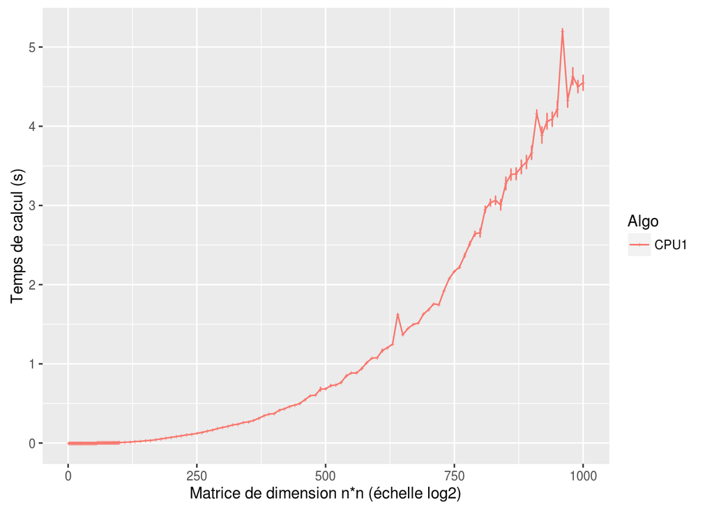

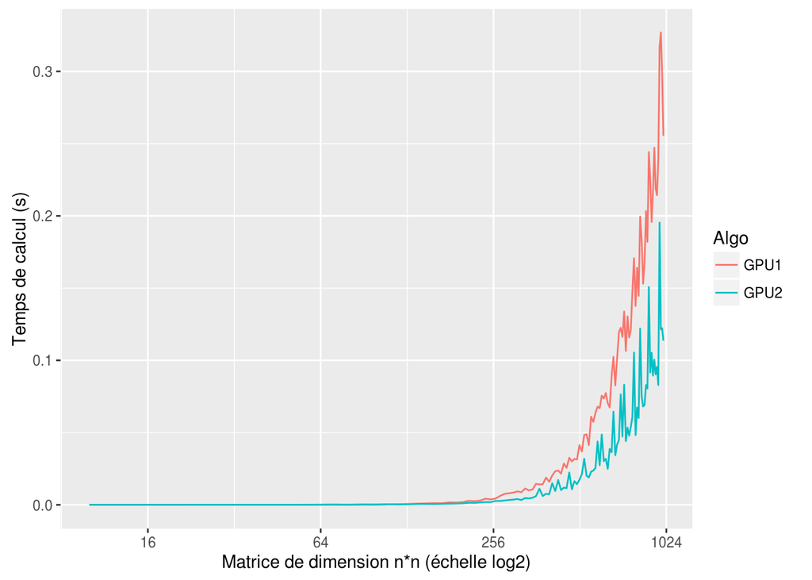

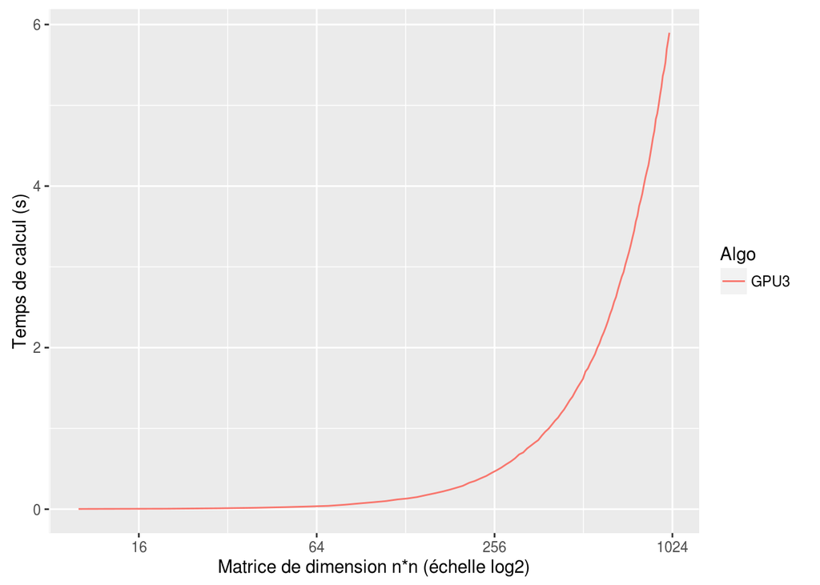

### 2 Temps d’allocation

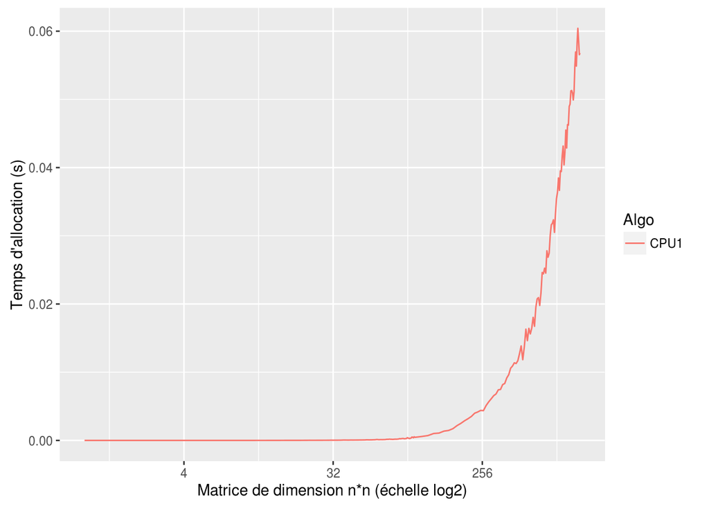

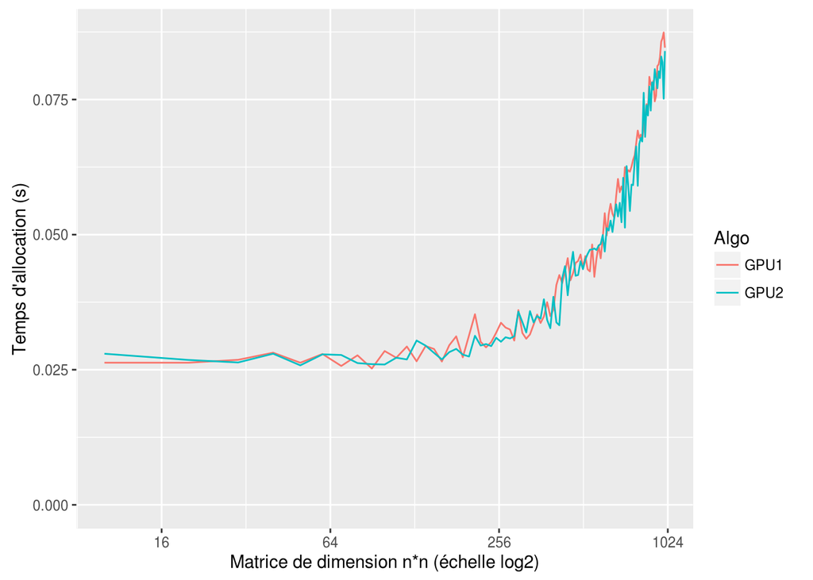

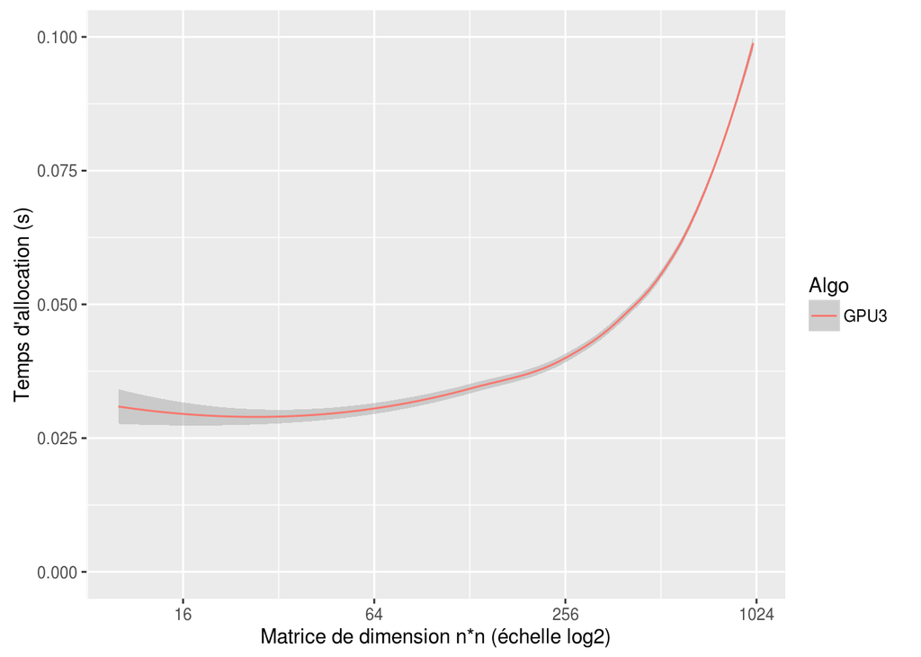

### 3 Temps total

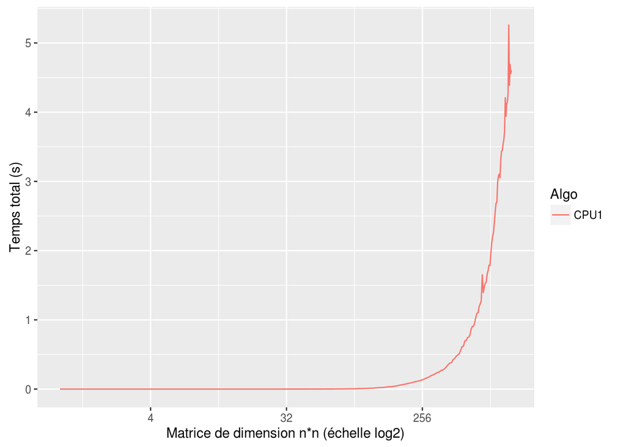

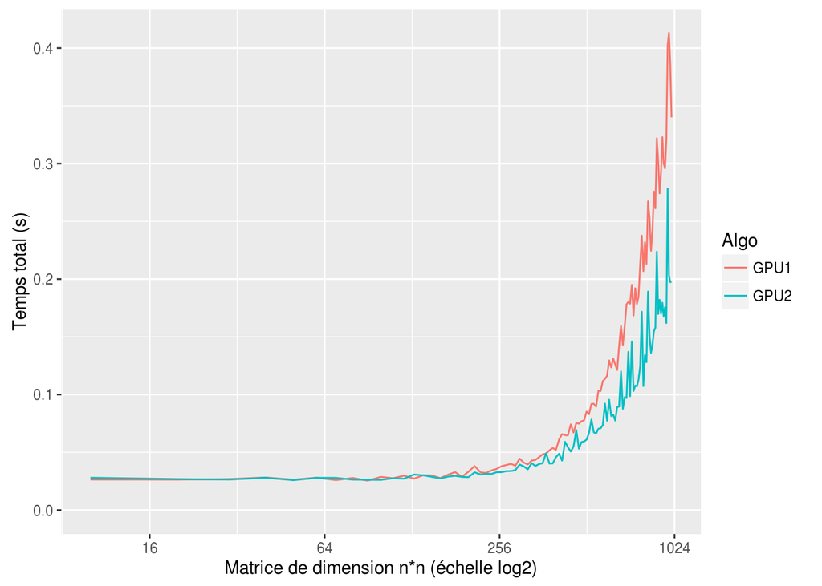

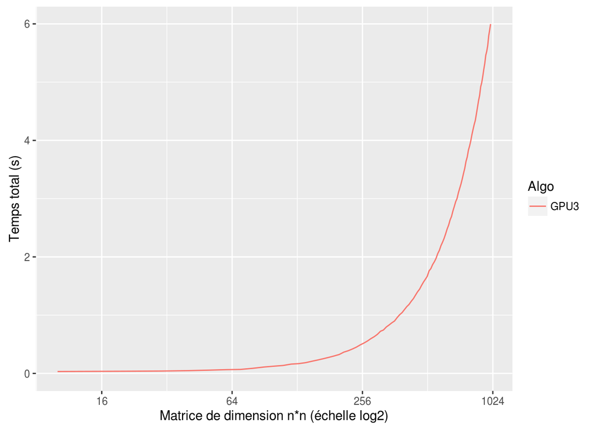

## III Conclusion

Grâce à cet expérience, nous avons pu saisir quelques prémices d’utilisation et de questionnement sur la programmation parrallèle sur GPU via le language CUDA, en nous basant sur la multiplication matricielle. Nous avons ainsi pu apréhender la méthode de pensées nécessaire à la parrallèlisation des calculs, ainsi que nous pencher sur les questions de transferts mémoires pouvant avoir un impact sur la vitesse de calculs.

Pour pousser plus loin sur la multiplication matricielle, il serait utile de faire varier l’emplacement mémoire pré-calcul pour introduire la variable dû à la localité ou non des données (ici, toutes les matrices étaient stockées sur la mémoire correspondant à leur unités de calcul [CPU ou GPU] respectives). Il pourrait aussi être intéressant d’adapter ces algorithmes pour des matrices n’étant pas forcément carrées, et d’observer les différences de performances induites.